# Wine Quality Feature Selection & Prediction Project

Autumn Heyman, Bethel Ikejiofor, Erin Weaver, Georgia Miller, Valerie Huston

Here we are taking a look at the quality of Vinho Verde wines within a region and select the more relevant physiochemical features that contribute to wine quality and in which ways. This will be achieved through the use of stepwise binary logistic regression.

# Importing Libraries

First we begin by *importing* our libraries.

```r
library(tidyverse)
library("caret")
library("lmtest")
library("magrittr")
library("dplyr")
library("tidyr")
library("popbio")
library("e1071")
library("PerformanceAnalytics")
```

```r
library("corrplot")
library(corpcor)
library("MASS")
```

# Importing our Dataset

Next we *import* our dataset.

```r
setwd('/Users/bethelikejiofor/Documents/GitHub/Fab-Five-Final-Project')
wine <- read.csv("./Data/WineQT.csv")

head(wine)
```

|  | fixed.acidity | volatile.acidity | citric.acid | residual.sugar | chlorides | free.sulfur.dioxide | total.sulfur.dioxide | density | pH | sulphates | alcohol | quality | Id |
| --- | --- | --- | --- | --- | --- | --- | --- | --- | --- | --- | --- | --- | --- |
| 1 | 7.4 | 0.70 | 0.00 | 1.9 | 0.076 | 11 | 34 | 0.9978 | 3.51 | 0.56 | 9.4 | 5 | 0 |
| 2 | 7.8 | 0.88 | 0.00 | 2.6 | 0.098 | 25 | 67 | 0.9968 | 3.20 | 0.68 | 9.8 | 5 | 1 |
| 3 | 7.8 | 0.76 | 0.04 | 2.3 | 0.092 | 15 | 54 | 0.9970 | 3.26 | 0.65 | 9.8 | 5 | 2 |
| 4 | 11.2 | 0.28 | 0.56 | 1.9 | 0.075 | 17 | 60 | 0.9980 | 3.16 | 0.58 | 9.8 | 6 | 3 |
| 5 | 7.4 | 0.70 | 0.00 | 1.9 | 0.076 | 11 | 34 | 0.9978 | 3.51 | 0.56 | 9.4 | 5 | 4 |
| 6 | 7.4 | 0.66 | 0.00 | 1.8 | 0.075 | 13 | 40 | 0.9978 | 3.51 | 0.56 | 9.4 | 5 | 5 |

# Some Data Wrangling

We beging by reformatting column names so there are no spaces.

```r
names(wine) <- str_replace_all(names(wine), c(" "="."))
```

Next, we proceed to drop the ID column since it will not be used in our analysis. We will also take a look again at the head of the dataframe to make sure the wrangling changes took effect.

```r
wine = subset(wine, select = -c(Id))
head(wine)
```

|  | fixed.acidity | volatile.acidity | citric.acid | residual.sugar | chlorides | free.sulfur.dioxide | total.sulfur.dioxide | density | pH | sulphates | alcohol | quality |
| --- | --- | --- | --- | --- | --- | --- | --- | --- | --- | --- | --- | --- |
| 1 | 7.4 | 0.70 | 0.00 | 1.9 | 0.076 | 11 | 34 | 0.9978 | 3.51 | 0.56 | 9.4 | 5 |
| 2 | 7.8 | 0.88 | 0.00 | 2.6 | 0.098 | 25 | 67 | 0.9968 | 3.20 | 0.68 | 9.8 | 5 |
| 3 | 7.8 | 0.76 | 0.04 | 2.3 | 0.092 | 15 | 54 | 0.9970 | 3.26 | 0.65 | 9.8 | 5 |
| 4 | 11.2 | 0.28 | 0.56 | 1.9 | 0.075 | 17 | 60 | 0.9980 | 3.16 | 0.58 | 9.8 | 6 |
| 5 | 7.4 | 0.70 | 0.00 | 1.9 | 0.076 | 11 | 34 | 0.9978 | 3.51 | 0.56 | 9.4 | 5 |
| 6 | 7.4 | 0.66 | 0.00 | 1.8 | 0.075 | 13 | 40 | 0.9978 | 3.51 | 0.56 | 9.4 | 5 |

# Assumptions Testing

For this project, rather than taking each of the individual quality levels and doing a logistic regression against them, we will recode the levels so wines either have either ‘good’ or ‘poor’ quality. Wines with a quality between 3 and 5 will fall into the ‘poor’ quality level and those between 6 and 8 will fall into the ‘good’ quality level.

## Recoding Wine Quality

```r
wine$qualityR <- NA
wine$qualityR[wine$quality==3] <- 0
wine$qualityR[wine$quality==4] <- 0
wine$qualityR[wine$quality==5] <- 0
wine$qualityR[wine$quality==6] <- 1
wine$qualityR[wine$quality==7] <- 1
wine$qualityR[wine$quality==8] <- 1
head(wine)
```

|  | fixed.acidity | volatile.acidity | citric.acid | residual.sugar | chlorides | free.sulfur.dioxide | total.sulfur.dioxide | density | pH | sulphates | alcohol | quality | qualityR |
| --- | --- | --- | --- | --- | --- | --- | --- | --- | --- | --- | --- | --- | --- |
| 1 | 7.4 | 0.70 | 0.00 | 1.9 | 0.076 | 11 | 34 | 0.9978 | 3.51 | 0.56 | 9.4 | 5 | 0 |
| 2 | 7.8 | 0.88 | 0.00 | 2.6 | 0.098 | 25 | 67 | 0.9968 | 3.20 | 0.68 | 9.8 | 5 | 0 |
| 3 | 7.8 | 0.76 | 0.04 | 2.3 | 0.092 | 15 | 54 | 0.9970 | 3.26 | 0.65 | 9.8 | 5 | 0 |
| 4 | 11.2 | 0.28 | 0.56 | 1.9 | 0.075 | 17 | 60 | 0.9980 | 3.16 | 0.58 | 9.8 | 6 | 1 |
| 5 | 7.4 | 0.70 | 0.00 | 1.9 | 0.076 | 11 | 34 | 0.9978 | 3.51 | 0.56 | 9.4 | 5 | 0 |
| 6 | 7.4 | 0.66 | 0.00 | 1.8 | 0.075 | 13 | 40 | 0.9978 | 3.51 | 0.56 | 9.4 | 5 | 0 |

## Running the Base Logistic Model

```r
mylogit <- glm(qualityR ~ fixed.acidity + volatile.acidity + citric.acid +
                  residual.sugar + chlorides + free.sulfur.dioxide + total.sulfur.dioxide+
                  density + pH + sulphates + alcohol, data = wine, family="binomial")
```

## Predicting Wine Quality

```r
probabilities <- predict(mylogit, type = "response")
```

Here, I will take the average of the probabilities from the prediction and anything that is above that probability will be classified as a good quality wine and anything below it will be classified as a poor quality wine.

```r
avg <- mean(probabilities)
wine$Predicted <- ifelse(probabilities > avg, "good", "poor")
head(wine)
```

|  | fixed.acidity | volatile.acidity | citric.acid | residual.sugar | chlorides | free.sulfur.dioxide | total.sulfur.dioxide | density | pH | sulphates | alcohol | quality | qualityR | Predicted |
| --- | --- | --- | --- | --- | --- | --- | --- | --- | --- | --- | --- | --- | --- | --- |
| 1 | 7.4 | 0.70 | 0.00 | 1.9 | 0.076 | 11 | 34 | 0.9978 | 3.51 | 0.56 | 9.4 | 5 | 0 | poor |
| 2 | 7.8 | 0.88 | 0.00 | 2.6 | 0.098 | 25 | 67 | 0.9968 | 3.20 | 0.68 | 9.8 | 5 | 0 | poor |
| 3 | 7.8 | 0.76 | 0.04 | 2.3 | 0.092 | 15 | 54 | 0.9970 | 3.26 | 0.65 | 9.8 | 5 | 0 | poor |
| 4 | 11.2 | 0.28 | 0.56 | 1.9 | 0.075 | 17 | 60 | 0.9980 | 3.16 | 0.58 | 9.8 | 6 | 1 | good |
| 5 | 7.4 | 0.70 | 0.00 | 1.9 | 0.076 | 11 | 34 | 0.9978 | 3.51 | 0.56 | 9.4 | 5 | 0 | poor |
| 6 | 7.4 | 0.66 | 0.00 | 1.8 | 0.075 | 13 | 40 | 0.9978 | 3.51 | 0.56 | 9.4 | 5 | 0 | poor |

## Recoding the Predicted Variable

```r
wine$PredictedR <- NA
```

```r
wine$PredictedR[wine$Predicted=="good"] <- 1
wine$PredictedR[wine$Predicted=="poor"] <- 0
head(wine)
```

|  | fixed.acidity | volatile.acidity | citric.acid | residual.sugar | chlorides | free.sulfur.dioxide | total.sulfur.dioxide | density | pH | sulphates | alcohol | quality | qualityR | Predicted | PredictedR |
| --- | --- | --- | --- | --- | --- | --- | --- | --- | --- | --- | --- | --- | --- | --- | --- |
| 1 | 7.4 | 0.70 | 0.00 | 1.9 | 0.076 | 11 | 34 | 0.9978 | 3.51 | 0.56 | 9.4 | 5 | 0 | poor | 0 |
| 2 | 7.8 | 0.88 | 0.00 | 2.6 | 0.098 | 25 | 67 | 0.9968 | 3.20 | 0.68 | 9.8 | 5 | 0 | poor | 0 |
| 3 | 7.8 | 0.76 | 0.04 | 2.3 | 0.092 | 15 | 54 | 0.9970 | 3.26 | 0.65 | 9.8 | 5 | 0 | poor | 0 |
| 4 | 11.2 | 0.28 | 0.56 | 1.9 | 0.075 | 17 | 60 | 0.9980 | 3.16 | 0.58 | 9.8 | 6 | 1 | good | 1 |
| 5 | 7.4 | 0.70 | 0.00 | 1.9 | 0.076 | 11 | 34 | 0.9978 | 3.51 | 0.56 | 9.4 | 5 | 0 | poor | 0 |
| 6 | 7.4 | 0.66 | 0.00 | 1.8 | 0.075 | 13 | 40 | 0.9978 | 3.51 | 0.56 | 9.4 | 5 | 0 | poor | 0 |

## Converting Variables to Factors

```r
wine$PredictedR <- as.factor(wine$PredictedR)
wine$qualityR <- as.factor(wine$qualityR)
head(wine)
```

|  | fixed.acidity | volatile.acidity | citric.acid | residual.sugar | chlorides | free.sulfur.dioxide | total.sulfur.dioxide | density | pH | sulphates | alcohol | quality | qualityR | Predicted | PredictedR |
| --- | --- | --- | --- | --- | --- | --- | --- | --- | --- | --- | --- | --- | --- | --- | --- |
| 1 | 7.4 | 0.70 | 0.00 | 1.9 | 0.076 | 11 | 34 | 0.9978 | 3.51 | 0.56 | 9.4 | 5 | 0 | poor | 0 |
| 2 | 7.8 | 0.88 | 0.00 | 2.6 | 0.098 | 25 | 67 | 0.9968 | 3.20 | 0.68 | 9.8 | 5 | 0 | poor | 0 |
| 3 | 7.8 | 0.76 | 0.04 | 2.3 | 0.092 | 15 | 54 | 0.9970 | 3.26 | 0.65 | 9.8 | 5 | 0 | poor | 0 |
| 4 | 11.2 | 0.28 | 0.56 | 1.9 | 0.075 | 17 | 60 | 0.9980 | 3.16 | 0.58 | 9.8 | 6 | 1 | good | 1 |
| 5 | 7.4 | 0.70 | 0.00 | 1.9 | 0.076 | 11 | 34 | 0.9978 | 3.51 | 0.56 | 9.4 | 5 | 0 | poor | 0 |
| 6 | 7.4 | 0.66 | 0.00 | 1.8 | 0.075 | 13 | 40 | 0.9978 | 3.51 | 0.56 | 9.4 | 5 | 0 | poor | 0 |

## Creating a Confusion Matrix

```r
conf_mat <- caret::confusionMatrix(wine$PredictedR, wine$qualityR)
conf_mat
```

```
## Confusion Matrix and Statistics
##
##           Reference
## Prediction   0   1
##          0 410 166
##          1 112 455
##
##                Accuracy : 0.7568
##                  95% CI : (0.7308, 0.7814)
##     No Information Rate : 0.5433
##     P-Value [Acc > NIR] : < 2.2e-16
##
##                   Kappa : 0.5139
##
##  Mcnemar's Test P-Value : 0.001479
##
##             Sensitivity : 0.7854
##             Specificity : 0.7327
##          Pos Pred Value : 0.7118
##          Neg Pred Value : 0.8025
##              Prevalence : 0.4567
##          Detection Rate : 0.3587
##    Detection Prevalence : 0.5039
##       Balanced Accuracy : 0.7591
##
##        'Positive' Class : 0
##
```

Thankfully, all of the four cells are above 5 so the sample size minimum is met.

## Logit Linearity

```r
wine1 <- wine %>% dplyr::select_if(is.numeric)
predictors <- colnames(wine1)
wine1 <- wine1 %>% mutate(logit=log(probabilities/(1-probabilities))) %>%
gather(key= "predictors", value="predictor.value", -logit)
```

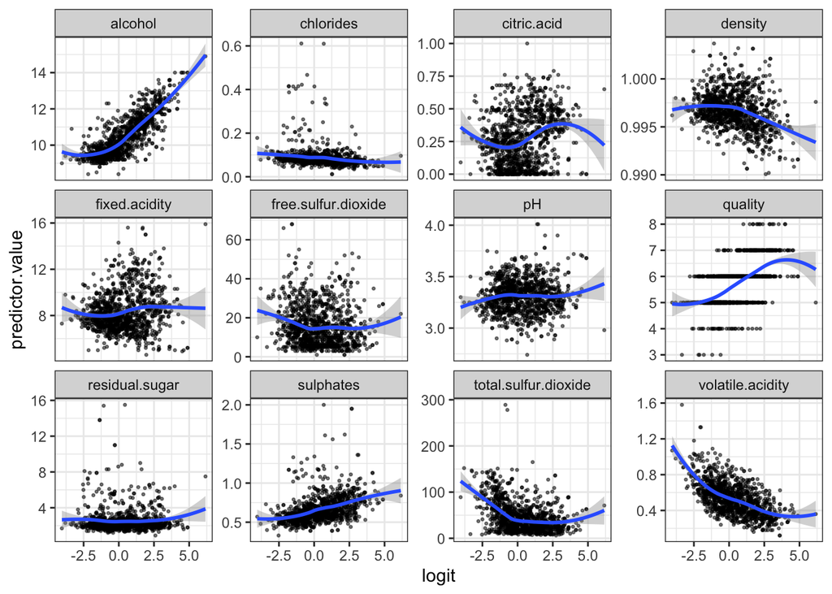

```r
ggplot(wine1, aes(logit, predictor.value))+
geom_point(size=.5, alpha=.5)+
geom_smooth(method= "loess")+
theme_bw()+
facet_wrap(~predictors, scales="free_y")
```

Most of the variables do not seem to have a linear logit relationship with wine quality so the assumption is not met. We will however proceed with our analyses.

## Multicollinearity

### Converting to Numeric

```r
wine$qualityR2 <- as.numeric(wine$qualityR)
head(wine)
```

|  | fixed.acidity | volatile.acidity | citric.acid | residual.sugar | chlorides | free.sulfur.dioxide | total.sulfur.dioxide | density | pH | sulphates | alcohol | quality | qualityR | Predicted | PredictedR | qualityR2 |
| --- | --- | --- | --- | --- | --- | --- | --- | --- | --- | --- | --- | --- | --- | --- | --- | --- |
| 1 | 7.4 | 0.70 | 0.00 | 1.9 | 0.076 | 11 | 34 | 0.9978 | 3.51 | 0.56 | 9.4 | 5 | 0 | poor | 0 | 1 |
| 2 | 7.8 | 0.88 | 0.00 | 2.6 | 0.098 | 25 | 67 | 0.9968 | 3.20 | 0.68 | 9.8 | 5 | 0 | poor | 0 | 1 |
| 3 | 7.8 | 0.76 | 0.04 | 2.3 | 0.092 | 15 | 54 | 0.9970 | 3.26 | 0.65 | 9.8 | 5 | 0 | poor | 0 | 1 |
| 4 | 11.2 | 0.28 | 0.56 | 1.9 | 0.075 | 17 | 60 | 0.9980 | 3.16 | 0.58 | 9.8 | 6 | 1 | good | 1 | 2 |
| 5 | 7.4 | 0.70 | 0.00 | 1.9 | 0.076 | 11 | 34 | 0.9978 | 3.51 | 0.56 | 9.4 | 5 | 0 | poor | 0 | 1 |
| 6 | 7.4 | 0.66 | 0.00 | 1.8 | 0.075 | 13 | 40 | 0.9978 | 3.51 | 0.56 | 9.4 | 5 | 0 | poor | 0 | 1 |

### Subsetting Data

```r
wine_subset <- wine[, c(1,2,3,4,5,6,7,8,9,10,11,16)]
```

### Testing for Correlation

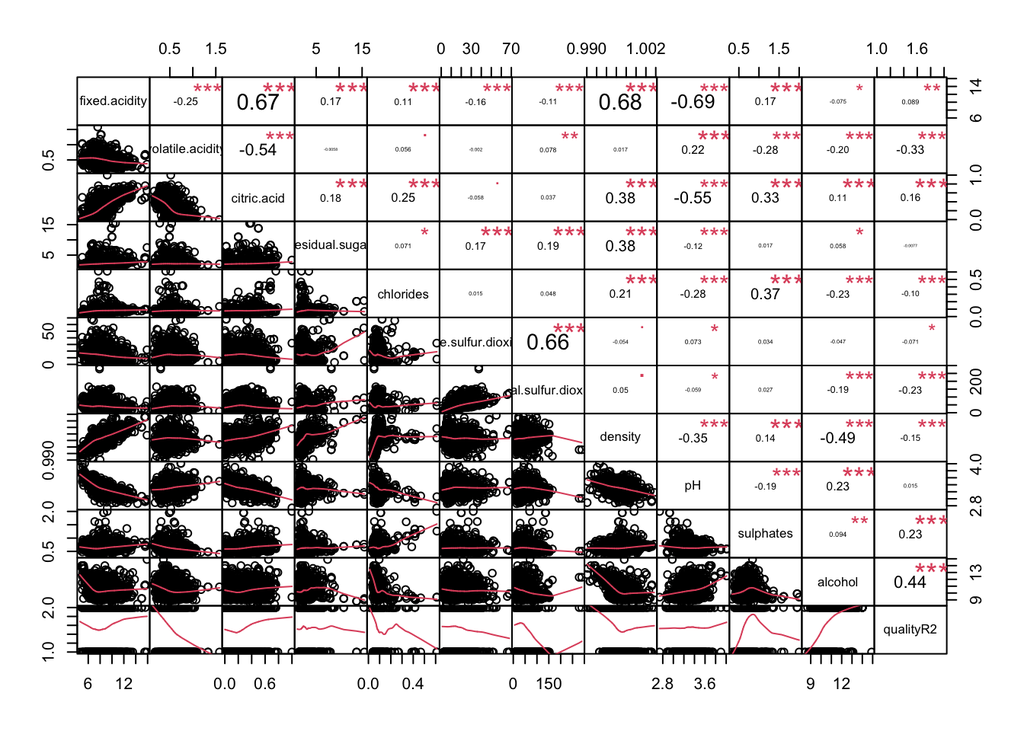

```r
chart.Correlation(wine_subset, histogram=FALSE, method="pearson")
```

```r
corr_matrix <- cor(wine_subset)
corr_matrix
```

```
##                      fixed.acidity volatile.acidity citric.acid residual.sugar
## fixed.acidity           1.00000000     -0.250728322  0.67315725    0.171830535
## volatile.acidity       -0.25072832      1.000000000 -0.54418694   -0.005751097
## citric.acid             0.67315725     -0.544186937  1.00000000    0.175814854
## residual.sugar          0.17183054     -0.005751097  0.17581485    1.000000000
## chlorides               0.10788857      0.056336259  0.24531249    0.070863112
## free.sulfur.dioxide    -0.16483079     -0.001962479 -0.05758910    0.165338797
## total.sulfur.dioxide   -0.11062837      0.077747722  0.03687111    0.190790035
## density                 0.68150088      0.016511520  0.37524326    0.380146952
## pH                     -0.68516260      0.221491518 -0.54633914   -0.116958936
## sulphates               0.17459183     -0.276078597  0.33123176    0.017474504
## alcohol                -0.07505485     -0.203909273  0.10625034    0.058420606
## qualityR2               0.08868227     -0.330786665  0.15514411   -0.007732109
##                        chlorides free.sulfur.dioxide total.sulfur.dioxide
## fixed.acidity         0.10788857        -0.164830793          -0.11062837
## volatile.acidity      0.05633626        -0.001962479           0.07774772
## citric.acid           0.24531249        -0.057589104           0.03687111
## residual.sugar        0.07086311         0.165338797           0.19079003
## chlorides             1.00000000         0.015280458           0.04816316
## free.sulfur.dioxide   0.01528046         1.000000000           0.66109287
## total.sulfur.dioxide  0.04816316         0.661092872           1.00000000
## density               0.20890071        -0.054150318           0.05017483
## pH                   -0.27775907         0.072803706          -0.05912572
## sulphates             0.37478389         0.034445122           0.02689368
## alcohol              -0.22991709        -0.047094832          -0.18816480
## qualityR2            -0.10060098        -0.070576946          -0.22667956
##                          density          pH   sulphates     alcohol
## fixed.acidity         0.68150088 -0.68516260  0.17459183 -0.07505485
## volatile.acidity      0.01651152  0.22149152 -0.27607860 -0.20390927
## citric.acid           0.37524326 -0.54633914  0.33123176  0.10625034
## residual.sugar        0.38014695 -0.11695894  0.01747450  0.05842061
## chlorides             0.20890071 -0.27775907  0.37478389 -0.22991709
## free.sulfur.dioxide  -0.05415032  0.07280371  0.03444512 -0.04709483
## total.sulfur.dioxide  0.05017483 -0.05912572  0.02689368 -0.18816480
## density               1.00000000 -0.35277462  0.14313929 -0.49472690
## pH                   -0.35277462  1.00000000 -0.18549903  0.22532220
## sulphates             0.14313929 -0.18549903  1.00000000  0.09442113
## alcohol              -0.49472690  0.22532220  0.09442113  1.00000000
## qualityR2            -0.15425452  0.01525117  0.23422114  0.44039706
##                         qualityR2
## fixed.acidity         0.088682270
## volatile.acidity     -0.330786665
## citric.acid           0.155144110
## residual.sugar       -0.007732109
## chlorides            -0.100600977
## free.sulfur.dioxide  -0.070576946
## total.sulfur.dioxide -0.226679557
## density              -0.154254520
## pH                    0.015251168
## sulphates             0.234221135
## alcohol               0.440397063
## qualityR2             1.000000000
```

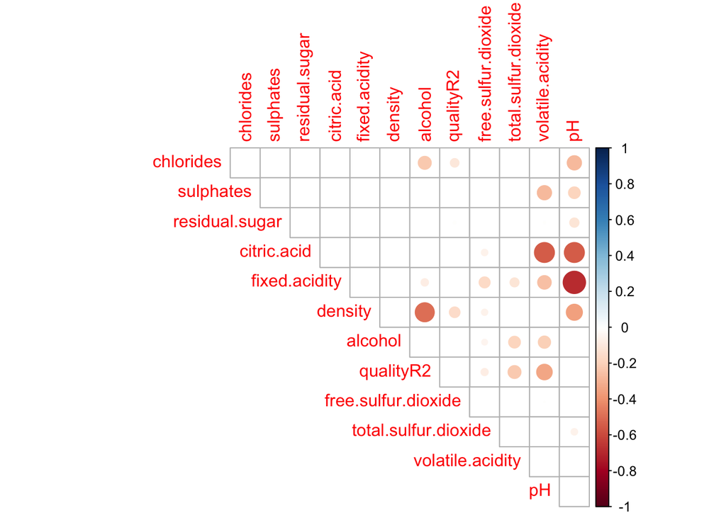

```r
corrplot(corr_matrix, type="upper", order="hclust", p.mat = corr_matrix, sig.level = 0.01, insig="blank")
```